# Song Project Stat 184

Yanki Saplan

December 8, 2020

#load the packages that is required within this project

```r
library(rvest)
library(tidyverse)
library(genius)
library(tidytext)
library(gridExtra)
library(ggplot2)
library(regexPipes)
library(dplyr)
data("stop_words")
data("sentiments")
```

#read the data from wikipedia, create a path for the link, and tables store them, print out the uncleaned the data table.

```r
# read webpage for Grammy Awards
webpage <- read_html("https://en.wikipedia.org/wiki/Grammy_Award_for_Record_of_the_Year")

# copy xpath for table of 1980s
XPATH80 <- '/html/body/div[3]/div[3]/div[5]/div[1]/table[5]'

# run the following to create table of songs from 1980s
table_1980 <-
  webpage %>%
  html_nodes(xpath = XPATH80) %>%
  html_table(fill = TRUE)

d1980 <- table_1980[[1]]
head(d1980)
```

|  | Year[I] | Record | Artist(s) | Production team |
| --- | --- | --- | --- | --- |
| 1 | 1980[44] | NA | NA | NA |
| 2 | 1980[44] | "What a Fool Believes" | The Doobie Brothers | Ted Templeman, producer |
| 3 | 1980[44] | "After the Love Has Gone" | Earth, Wind & Fire | Maurice White, producer |
| 4 | 1980[44] | "I Will Survive" | Gloria Gaynor | Freddie Perren & Dino Fekaris, producers |
| 5 | 1980[44] | "The Gambler" | Kenny Rogers | Larry Butler, producer |
| 6 | 1980[44] | "You Don't Bring Me Flowers" | Barbra Streisand & Neil Diamond | Bob Gaudio, producer |

#cleaning the data table and renaming it to ROY80s by calling table d1980, renaming old column names to new names, get rid of empty NA values, lastly get rid of any brackets present inside the table for the purpose of cleaning. Insert lyrics by genius function to each ROY

```r
#change the table name to ROY80s
ROY80s <- d1980
#changing the column names
  ROY80s <-
  ROY80s %>%
  select(`Year[I]`, Record, `Artist(s)`) %>%
  rename(year = `Year[I]`,
        track = Record,
        artist = `Artist(s)`)
#remove na s from the table
  ROY80s <-
  ROY80s %>%
  na.omit()
#Remove the brackets, from the [1] Year column
  ROY80s <-
  ROY80s %>%
  mutate(year = trimws(str_replace(year, "\\[.*?\\]","")))

#get the lyrics for the songs listed under 1980s
  lyrics80s <- ROY80s %>%
    add_genius(artist, track, type = "lyrics")
```

[output not shown]

```r
head(ROY80s)
```

|  | year | track | artist |
| --- | --- | --- | --- |
| 1 | 1980 | "What a Fool Believes" | The Doobie Brothers |
| 2 | 1980 | "After the Love Has Gone" | Earth, Wind & Fire |
| 3 | 1980 | "I Will Survive" | Gloria Gaynor |
| 4 | 1980 | "The Gambler" | Kenny Rogers |
| 5 | 1980 | "You Don't Bring Me Flowers" | Barbra Streisand & Neil Diamond |
| 6 | 1981 | "Sailing" | Christopher Cross |

```r
# read webpage for Grammy Awards
webpage <- read_html("https://en.wikipedia.org/wiki/Grammy_Award_for_Record_of_the_Year")

# copy xpath for table of 1990s
XPATH90 <- '/html/body/div[3]/div[3]/div[5]/div[1]/table[6]'

# run the following to create table of songs from 1990s
table_1990 <-
  webpage %>%
  html_nodes(xpath = XPATH90) %>%
  html_table(fill = TRUE)

d1990 <- table_1990[[1]]
head(d1990)
```

|  | Year[I] | Record | Artist(s) | Production team |
| --- | --- | --- | --- | --- |
| 1 | 1990[54] | NA | NA | NA |
| 2 | 1990[54] | "Wind Beneath My Wings" | Bette Midler | Arif Mardin, producer |
| 3 | 1990[54] | "The End of the Innocence" | Don Henley | Don Henley & Bruce Hornsby, producers |
| 4 | 1990[54] | "She Drives Me Crazy" | Fine Young Cannibals | David Z & Fine Young Cannibals, producers |
| 5 | 1990[54] | "We Didn't Start the Fire" | Billy Joel | Mick Jones & Billy Joel, producers |
| 6 | 1990[54] | "The Living Years" | Mike + The Mechanics | Christopher Neil & Mike Rutherford, producers |

```r
#change the table name to ROY90s
ROY90s <- d1990
#changing the column names
  ROY90s <-
  ROY90s %>%
  select(`Year[I]`, Record, `Artist(s)`) %>%
  rename(year = `Year[I]`,
        track = Record,
        artist = `Artist(s)`)
#remove na s from the table
  ROY90s <-
  ROY90s %>%
  na.omit()
#Remove the brackets, from the [1] Year column
  ROY90s <-
  ROY90s %>%
  mutate(year = trimws(str_replace(year, "\\[.*?\\]","")))

#get the lyrics for the songs listed under 1990s
  lyrics90s <- ROY90s %>%
    add_genius(artist, track, type = "lyrics")
```

[output not shown]

```r
head(ROY90s)
```

|  | year | track | artist |
| --- | --- | --- | --- |
| 1 | 1990 | "Wind Beneath My Wings" | Bette Midler |
| 2 | 1990 | "The End of the Innocence" | Don Henley |
| 3 | 1990 | "She Drives Me Crazy" | Fine Young Cannibals |
| 4 | 1990 | "We Didn't Start the Fire" | Billy Joel |
| 5 | 1990 | "The Living Years" | Mike + The Mechanics |
| 6 | 1991 | "Another Day in Paradise" | Phil Collins |

```r
# read webpage for Grammy Awards
webpage <- read_html("https://en.wikipedia.org/wiki/Grammy_Award_for_Record_of_the_Year")

# copy xpath for table of 2000s
XPATH00 <- '/html/body/div[3]/div[3]/div[5]/div[1]/table[7]'

# run the following to create table of songs from 2000s
table_2000 <-
  webpage %>%
  html_nodes(xpath = XPATH00) %>%
  html_table(fill = TRUE)

d2000 <- table_2000[[1]]
head(d2000)
```

|  | Year[I] | Record | Artist(s) | Production team |
| --- | --- | --- | --- | --- |
| 1 | 2000[64] | NA | NA | NA |
| 2 | 2000[64] | "Smooth" | Santana featuring Rob Thomas | Matt Serletic, producer; David Thoener, engineer/mixer |
| 3 | 2000[64] | "Believe" | Cher | Brian Rawling & Mark Taylor, producers; Mark Taylor, engineer/mixer |
| 4 | 2000[64] | "I Want It That Way" | Backstreet Boys | Kristian Lundin & Max Martin, producers; Kristian Lundin & Max Martin, engineers/mixers |
| 5 | 2000[64] | "Livin' la Vida Loca" | Ricky Martin | Desmond Child & Robi Rosa, producers; Charles Dye, engineer/mixer |
| 6 | 2000[64] | "No Scrubs" | TLC | Kevin "Shekspere" Briggs, producer; Leslie Brathwaite & Carlton Lynn, engineers/mixers |

```r
#change the table name to ROY00s
ROY00s <- d2000
#changing the column names
ROY00s <-
  ROY00s %>%
  select(`Year[I]`, Record, `Artist(s)`) %>%
  rename(year = `Year[I]`,
        track = Record,
        artist = `Artist(s)`)
#remove na s from the table
  ROY00s <-
  ROY00s %>%
  na.omit()
#Remove the brackets, from the [1] Year column
  ROY00s <-
  ROY00s %>%
  mutate(year = trimws(str_replace(year, "\\[.*?\\]","")))

#get the lyrics for the songs listed under 2000s
  lyrics00s <- ROY00s %>%
    add_genius(artist, track, type = "lyrics")
```

[output not shown]

```r
head(ROY00s)
```

|  | year | track | artist |
| --- | --- | --- | --- |
| 1 | 2000 | "Smooth" | Santana featuring Rob Thomas |
| 2 | 2000 | "Believe" | Cher |
| 3 | 2000 | "I Want It That Way" | Backstreet Boys |
| 4 | 2000 | "Livin' la Vida Loca" | Ricky Martin |
| 5 | 2000 | "No Scrubs" | TLC |
| 6 | 2001 | "Beautiful Day" | U2 |

```r
# read webpage for Grammy Awards
webpage <- read_html("https://en.wikipedia.org/wiki/Grammy_Award_for_Record_of_the_Year")

# copy xpath for table of 2010s
XPATH12 <- '/html/body/div[3]/div[3]/div[5]/div[1]/table[8]'


# run the following to create table of songs from 2010s
table_2010 <-
  webpage %>%
  html_nodes(xpath = XPATH12) %>%
  html_table(fill = TRUE)


d2010 <- table_2010[[1]]
head(d2010)
```

|  | Year[I] | Record | Artist(s) | Production team |
| --- | --- | --- | --- | --- |
| 1 | 2010[74] | NA | NA | NA |
| 2 | 2010[74] | "Use Somebody" | Kings of Leon | Jacquire King & Angelo Petraglia, producers; Jacquire King, engineer/mixer |
| 3 | 2010[74] | "Halo" | Beyoncé | Beyoncé Knowles & Ryan Tedder, producers; Jim Caruana, Mark "Spike" Stent & Ryan Tedder, engineers/mixers |
| 4 | 2010[74] | "I Gotta Feeling" | The Black Eyed Peas | David Guetta & Frederick Riesterer, producers; will.i.am, Dylan "3-D" Dresdow & Padraic "Padlock" Kerin, engineers/mixers |
| 5 | 2010[74] | "Poker Face" | Lady Gaga | RedOne, producer; Robert Orton, RedOne & Dave Russell, engineers/mixers |
| 6 | 2010[74] | "You Belong with Me" | Taylor Swift | Nathan Chapman & Taylor Swift, producers; Chad Carlson & Justin Niebank, engineers/mixers |

```r
#change the table name to ROY10s
ROY10s <- d2010
#changing the column names
  ROY10s <-
  ROY10s %>%
  select(`Year[I]`, Record, `Artist(s)`) %>%
  rename(year = `Year[I]`,
        track = Record,
        artist = `Artist(s)`)
#remove na s from the table
  ROY10s <-
  ROY10s %>%
  na.omit()
#Remove the brackets, from the [1] Year column
  ROY10s <-
  ROY10s %>%
  mutate(year = trimws(str_replace(year, "\\[.*\\]","")))

#get the lyrics for the songs listed under 2010s
  lyrics10s <- ROY10s %>%
    add_genius(artist, track, type = "lyrics")
```

[output not shown]

```r
head(ROY10s)
```

|  | year | track | artist |
| --- | --- | --- | --- |
| 1 | 2010 | "Use Somebody" | Kings of Leon |
| 2 | 2010 | "Halo" | Beyoncé |
| 3 | 2010 | "I Gotta Feeling" | The Black Eyed Peas |
| 4 | 2010 | "Poker Face" | Lady Gaga |
| 5 | 2010 | "You Belong with Me" | Taylor Swift |
| 6 | 2011 | "Need You Now" | Lady Antebellum |

#Binding all the lyrics varibles who has genius in them,(also cleaned) to a new variable called new1

```r
new1 <- rbind(lyrics80s, lyrics90s, lyrics00s, lyrics10s)
```

#merge it to a variable called lyric4

```r
lyrics4 <- new1
```

#unnest tokens inside the lyric4

```r
lyrics4 <- lyrics4 %>%
  unnest_tokens(word, lyric)
```

```r
lyrics4 <- lyrics4%>%
  group_by(track, decade) %>%
  summarise(count = sum(n()))
```

#ifelse did not work some reason, use case_when instead when each year ranges fall into the designated categories rename them for the sake of decade

```r
lyrics4 <- lyrics4 %>%
  rowwise() %>%
  mutate(decade = case_when( year %in% 1980:1989 ~ "1980s",
                             year %in% 1990:1999 ~ "1990s",
                             year %in% 2000:2009 ~ "2000s",
                             year %in% 2010:2019 ~ "2010s"))
# function worked after trying it with case_when, although it doesnt output now because the graph is already made and year is not present inside lyrics3 anymore
```

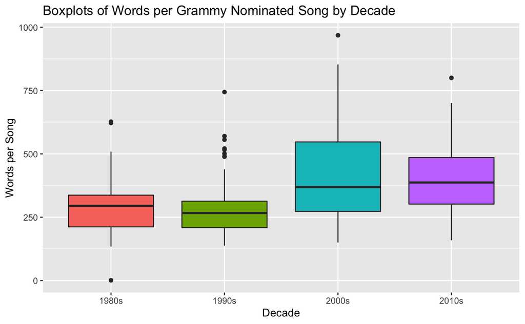

```r
#graph of first box plot
lyrics4 %>%
    ggplot(aes(x = decade, y = count, fill=decade)) +
    geom_boxplot() +
    theme(legend.position = "None")+
    xlab("Decade")+
    ylab("Words per Song")+
    ggtitle("Boxplots of Words per Grammy Nominated Song by Decade")
```

#graph above prints out boxplots that represents the words per grammy nominated songs by using the decade variable we have integrated within our code. And compares each decade by using words per song tag.

#creating a new data frame to store words used by artists, later on this frame will be used to antijoin from the main data

```r
data_stopwords <-data.frame(word = c("ba", "du", "yeah", "da", "ya", "ooh", "gonna", "na", "uh", "la", "hol"))
```

#bind lyrics into a new variable

```r
NewGraph <- rbind(lyrics80s, lyrics90s, lyrics00s, lyrics10s)
NewGraph <-
  NewGraph %>%
  unnest_tokens(word, lyric)
```

#anti joining stop words and data stop words from the new graph

```r
NewGraph <-
  NewGraph %>%
  anti_join(data_stopwords, by = c("word"="word")) %>%
  anti_join(stop_words, by = c("word"="word"))
```

#filtering for the graph visualization

```r
NewGraph <-
  NewGraph %>%
  count(word, sort = TRUE)%>%
  filter(n >= 3)%>%
  top_n(10)
```

#After running the codes needed for our second graph, we count and sort the words inside our graphing variable(NewGraph), we use antijoin function to get rid of the stopwords and data stopwords that we defined above. We order each word by word for the x axis, get rid of the legend, and fill them by color of our choice.

```
Ignoring unknown parameters: stat
```

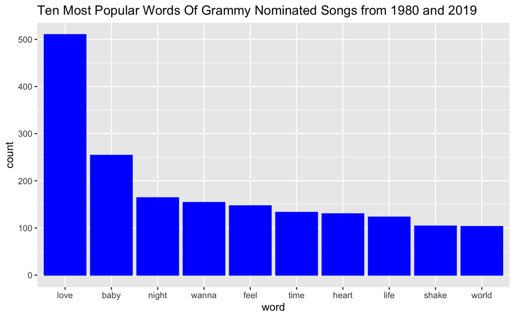

```r
NewGraph%>%
  ggplot(aes(x = reorder(word, -n), y =n))+
  geom_col(stat = 'identity', color = 'blue', fill = 'blue')+
  xlab("word")+
  ylab("count")+
  theme(legend.position = "none")+
  ggtitle("Ten Most Popular Words Of Grammy Nominated Songs from 1980 and 2019")
```

#the graph above represents the difference of each word that is being used artists across our data table, we count and filter all the top ten words and graph them with our count and word variables, to demonstrate the understanding of which words were used the most during these decades.

```r
# create data frame of top 10 words
# occur at least 3 times
# remove common words using stop_word list in tidytext package
# plot
# using count from tidytext package
ft <- verse_words %>%
  anti_join(stop_words)
```

[output not shown]

#Code chunks below are for Graph 3 Implementation

```r
Graph3first <- lyrics80s
```

# carry the lyrics by each decade inside to first graphing variable starting by 1980s, this procedure has done to each decade. The purpose of this is to classify each decades graphing variable, so when we graph them, we have 2 columns by 2 rows for each decade.

```r
Graph3first <-
  Graph3first %>%
  unnest_tokens(word, lyric)
```

```r
Graph3first <-
  Graph3first %>%
  anti_join(data_stopwords, by = c("word"="word")) %>%
  anti_join(stop_words, by = c("word" = "word")) %>%
  mutate(
    decade = case_when( year %in% 1980:1989 ~ "1980s")
  )
```

```r
Graph3first <- Graph3first %>%
  group_by(year, decade) %>%
  count(word, sort = TRUE) %>%
  filter( n >= 3) %>%
  ungroup() %>%
  top_n(10)
```

```r
Graph3sec <- lyrics90s
```

```r
Graph3sec <-
  Graph3sec %>%
  unnest_tokens(word, lyric)
```

```r
Graph3sec <-
  Graph3sec %>%
  anti_join(data_stopwords, by = c("word"="word")) %>%
  anti_join(stop_words, by = c("word" = "word")) %>%
  mutate(
    decade = case_when( year %in% 1990:1999 ~ "1990s")
  )
```

```r
Graph3sec <- Graph3sec %>%
  group_by(year, decade) %>%
  count(word, sort = TRUE) %>%
  filter( n >= 3) %>%
  ungroup() %>%
  top_n(10)
```

```r
Graph3third <- lyrics00s
```

```r
Graph3third <-
  Graph3third %>%
  unnest_tokens(word, lyric)
```

```r
Graph3third <-
  Graph3third %>%
  anti_join(data_stopwords, by = c("word"="word")) %>%
  anti_join(stop_words, by = c("word" = "word")) %>%
  mutate(
    decade = case_when( year %in% 2000:2009 ~ "2000s")
  )
```

```r
Graph3third <- Graph3third %>%
  group_by(year, decade) %>%
  count(word, sort = TRUE) %>%
  filter( n >= 3) %>%
  ungroup() %>%
  top_n(10)
```

```r
Graph3fourth <- lyrics10s
```

```r
Graph3fourth <-
  Graph3fourth %>%
  unnest_tokens(word, lyric)
```

```r
Graph3fourth <-
  Graph3fourth %>%
  anti_join(data_stopwords, by = c("word"="word")) %>%
  anti_join(stop_words, by = c("word" = "word")) %>%
  mutate(
    decade = case_when( year %in% 2010:2019 ~ "2010s")
  )
```

```r
Graph3fourth <- Graph3fourth %>%
  group_by(year, decade) %>%
  count(word, sort = TRUE) %>%
  filter( n >= 3) %>%
  ungroup() %>%
  top_n(10)
```

#merging all the data we created above for graphing 3

```r
mygraph1 <-Graph3first %>%
  ggplot(aes(x = reorder(word, -n), y = n)) +
  geom_bar(stat = 'identity', color = 'black', fill = 'black')+
  theme_minimal() +
  ggtitle("1980s")+
  xlab("Word")+
  ylab("Count")+
  theme(legend.position = "none")
```

#creating each decades graphing variable and putting our graph variables inside the ggplot for each decade

```r
mygraph2 <-Graph3sec %>%
  ggplot(aes(x = reorder(word, -n), y = n)) +
  geom_bar(stat = 'identity', color = 'green', fill = 'green')+
  theme_minimal() +
  ggtitle("1990s")+
  xlab("Word")+
  ylab("Count")+
  theme(legend.position = "none")
```

```r
mygraph3 <-Graph3third %>%
  ggplot(aes(x = reorder(word, -n), y = n)) +
  geom_bar(stat = 'identity', color = 'red', fill = 'red')+
  theme_minimal() +
  ggtitle("2000s")+
  xlab("Word")+
  ylab("Count")+
  theme(legend.position = "none")
```

```r
mygraph4 <-Graph3fourth %>%
  ggplot(aes(x = reorder(word, -n), y = n)) +
  geom_bar(stat = 'identity', color = 'blue', fill = 'blue')+
  theme_minimal() +
  ggtitle("2010s")+
  xlab("Word")+
  ylab("Count")+
  theme(legend.position = "none")
```

#The procedure of making this graph, included creating and carrying decade lyrics variables into a new variable, getting rid of the stop words and our data stop words, counting them by year and decade variables that are present inside the graph. Lastly mergin each decades cleaned variables into the graphing variables and specifying rows and columns we need to graph this in four different window method.

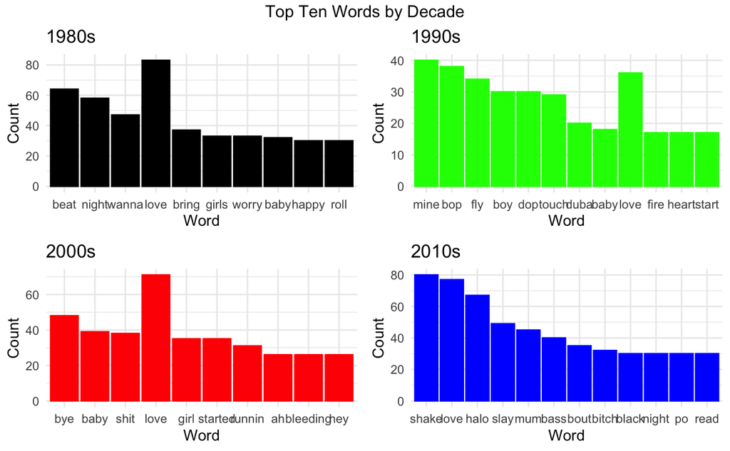

```r
grid.arrange(mygraph1, mygraph2, mygraph3, mygraph4, nrow =2, ncol=2, top = "Top Ten Words by Decade")
```

#Implementation of Graph4

```r
Graphic4 <- rbind(lyrics80s, lyrics90s, lyrics00s, lyrics10s)
```

#Rename the sentiment values negative, postive into 1s and 0s

```r
sentiments <-
  sentiments %>%
  mutate(truthvalue = case_when( sentiment %in% "negative" ~ "0",
                                 sentiment %in% "positive" ~ "1"))
```

#after error we have to specify year column is numeric

```r
Graphic4$year <- as.numeric(as.character(Graphic4$year))
```

```r
Graphic4 <-
  Graphic4 %>%
  count(truthvalue)
```

#count new column name data

```r
Graphic4 <-
  Graphic4 %>%
  anti_join(data_stopwords, by = c("word"="word")) %>%
  anti_join(stop_words, by = c("word"="word")) %>%
  mutate(decade = case_when( year %in% 1980:1989 ~ "1980s",
                             year %in% 1990:1999 ~ "1990s",
                             year %in% 2000:2009 ~ "2000s",
                             year %in% 2010:2019 ~ "2010s"))%>%
  inner_join(sentiments, by = "word") %>%
  group_by(year, decade, sentiment, truthvalue)
```

#specifying the decades using case_when

```r
Graphic4 <-
  Graphic4 %>%
  filter(truthvalue ==1)
```